# Prosjektoppgave - Gustav Gabrielsen

## Elektrifiseringen av sokkelen - Prosjektoppgave

#### Gustav Gabrielsen

```python
import pandas as pd
from matplotlib import pyplot as plt
import requests
from pyjstat import pyjstat
import seaborn as sns
```

#### Arbeidskrav 1

1. Gjør en vurdering av tiltaket ihht. DFØs veilder og identifiser hvilken informasjon som trengs og hvilke forutsetninger som må gjøres.
2. Innhent informasjon
3. Sette opp en disposisjon/arbeidsplan (bruk veilederen)

Tiltak: Elektrifiseringen av norsk sokkel.

Nytte:

- Redusere utslipp av CO2
- Langsiktige kostnads reduksjoner
- Frigjort gass til annen produksjon og eksport
- Redusere eksternaliteter

Ringvirkninger:

- Potensiellt økte strømpriser
- Mindre kraft for annen industri
- Utvikling av grønn energi (havvind og landvind)

Virkninger:

- Frigjort gass som kan selges i kraftmarkedet
- Forlenge produksjon av norsk olje og gass

Kostnader:

- Utgifter knyttet til utbygging av ny infrastruktur
- Strømkostander
- Subsidier

### Disposisjon (med forbehold om endringer)

- Beskriv problemet og gi bakgrunns info.

Beskriv problemene knyttet til utslippene av klimagasser fra olje- og gass sektoren. Se på historiske tall. Forklar hvordan markedet for kraft i Europa fungerer. Se nærmere på klimavtaler og mål ved elektrifiseringen.

- Sammendrag av hovedfunn og anbefalinger.

Gi et sammendrag av de viktigste funnene fra analysen.

Bakgrunn, mål, konsekvenser og funn i analysen (anbefalinger)

- Datakilder, metode og andre sentrale forutsetninger.

Viktig at data er lett tilgjengelige, slik at resultatene kan kvalitets sjekkes.

#### Oppbyggning av oppgaven:

- Hva er problemet og hva vil vi oppnå.

Adresser problemene knyttet til CO2 utslipp, og forklar hva vil vi oppnå ved et tiltak.

- Hvilke tiltak er relevante?

Presenter og beskriv alternative tiltak.

Nullalternativ, berørte parter, (sunk cost)?

- Hvilke prinsipielle spørsmål reiser tiltakene?

Prinsipielle spørsmål kan innebære å utelukke eller begrunne begrensninger av alternative tiltak som er identifisert.

- Hva er de positive og negative virknignene av tiltakene, hvor varige er de, og hvem blir berørt?

#### Problemstilling

Hva er oppdraget? Elektrifiseringen av sokkelen.

Hva er målet med elektrifiseringen? Erstatte gassturbiner med kraft fra land.

Hvilke forutsetnigner må gjøres?

Identifiser virkninger. Tallfest, verdsett og vurder virkninger.

Utredninger:

Elektrifiseringen av sokkelen:

- Kostnader for investeringer i infrastruktur
- Kostnader for strøm
- CO2 kvoter
- Eksport av gass
- Inntekter for kvoter

Alternative tiltak:

- Kostnader
- Opportunity cost

Begge:

- Velferd og omfordelings effekter
- Samfunnsøkonomisk lønnsomhet

Hvilke tiltak anbefales, og hvorfor?

Gi en samlet vurdering og anbefalte tiltak. Presenter en plan for når og hvordan tiltaket skal evalureres.

- Hva er forutsetnignene for en vellykket gjennomføring?

Synliggjør for beslutningstakeren sentrale forutsetninger som må være oppfylt for at tiltaket skal lykkes, og utarbeide en gevinstoversikt.

- Eventuelle tillegsanalyser: Fordelingsvirkninger, prinsipielle spørsmål, vurdering av graden av måloppnåelse eller målkonflikter og netto ringvirkninger.

## Grovanalyse - elektrifisering av norsk sokkel

#### 1. Hva er problemet, og hva vil vi oppnå?

Utredningen skal addressere er utslippene av klimagasser fra olje- og gassektoren og hvordan disse påvirker det nasjonale og globale klimaet. I dag er det over 160 gassturbiner som brukes til å produsere kraft på norsk sokkel, og som utgjør med fakling (etterforbrenning for å blir kvitt overflødig gass) 90.6% av de samlede CO2 - utslipene (Equinor u.å).

Resultatet av en slik elektrifiseringen er avhengig av flere faktorer: En viktig forutsetning er hvordan gassen som frigjøres fra plattformene anvendes, noe som henger sammen med de ulike virkningsgradene når gass blir brukt til produksjon. Ulike metoder for å bruke gass vil ha forskjellige virkningsgrader, for eksempel vil en gassturbin på sokkelen ha en annen virkningsgrad sammenlignet med et landbasert kraftverk. Høy virkningsgrad gir et mer energieffektivt forbruk av gass, sagt på en annen måte fører en lavere virkingsgrad til et større energitap, der en lavere andel av gassen blir omdannet til nyttig energi. I tilegg spiller det en viktig rolle om bruken av den frigjorte gassen regnes som et tilegg til produksjonen, eller om den erstatter annen produksjon. Dersom den frigjorte gassen benyttes til nye formål uten å redusere bruken av andre energikilder, vil dette bare være et tilegg som ikke nødvendigvis reduserer det totale utslippet. Ideelt sett bør bruken av frigjort gass se på muligheter for å erstatte mer forurensende energikilder, slik som kull eller olje. Dette vil redusere netto CO2 - utslipp.

For elektrifiseringen av sokkelen, vil et nullalternativ se slik ut: Ingen elektrifisering vil medføre at plattformene fortsetter å bruke gassturbiner for kraftproduksjon og behov på plattformene. Fakling av gass vil fortsette som en løsning for å håndtere overskuddsgass som ikke kan anvendes eller transporteres. Energiforsyningen til plattformene vil være basert på fossile brensler, med tilhørende utslipp, ingen implementering av fornybare energikilder eller alternative lavutslippskilder fra land. CO2 - utslippene vil forbli på samme nivå eller økes som følge av aldring av plattformene. Dette vil påvirke Norge sine muligheter til å nå nasjonale og globale klimamål. Norge vil som en konsekvens av dette fortsette å stå ovenfor press fra internasjonale og nasjonale klimaforpliktelser. Potensielt sett vil Norge kunne møte kritikk og økt offentlig og politisk press for å ikke tilpasse seg til moderne klimakrav. Vedlikehold av turbiner vil fortsette å kreve betydelige investeringer. Potensielt høyere langsiktige driftskostnader på grunn av stigende priser på fossilebrensler og karbon avgifter. CO2 - utslippene vil også ha en rekke negative påvirkninger på lokalt og globalt miljø gjennom utslipp av klimagasser, det er også potensielle helsemessige og økologiske konsekvenser for ansatte og marine økosystemer i nærhetene av plattformene.

Elektrifiseringen tar sikte på å oppnå klimamål i Norge samtidig som det skal bidra til en reduksjon av de europeiske og globale klimagassutslippene via markedsendringer i kraft- og gassmarkedene. Selvom det norske kraftsystemet i hovedsak er basert på vannkraft, er det norske systemet knyttet til det nordiske og europeiske markedet. I hovednettet varierer eksport og import av kraft over tid, og mellom regioner.

Elektrifiseringen av denne sektoren har som mål å redusere utslippene gjennom en overgang fra å bruke fossile brensler offshore til fornybar eller lavutslipp energikilder fra land.

#### 2. Hvilke tiltak er relevante?

Elektrifiseringen av sokkelen:

- Implementering av elektrifiseringsprosjekter på norsk sokkel, som for eksempel å erstatte gassturbiner med kraft fra land.
- Øke investeringene i fornybar energi og lavutslipps kraftproduksjon i Europa for å møte det økte kraftbehovet fra norsk sokkel.
- Et lavere og mer effektivt energiforbruk offshore for å maksimere klimanytten av elektrifisering.

#### 3. Hvilke prinsipielle spørsmål reiser tiltakene?

Prinsipielle spørsmål:

- Rettferdigheten av kostnadsfordelingen mellom oljeselskapene og samfunnet, spesielt i forhold til hvem som må bære kostnadene for infrastrukturinvesteringer.
- Langsiktig holdbarhet og politisk engasjement for å opprettholde støtte til elektrifiseringsprosjekter.
- Effekten av elektrifiserig på karbonlekkasje, hvor reduksjoner i et område kan føre til øke utslipp et annet sted gjennom markedsendringer.

Notat:

Utredninger av prinsipielle hensyn, inngår ikke i samfunnsøkonomiske analyser, men vil kreve en egen analyse. Videre følger det av Finansdepartementets rundskriv for samfunnsøkonomiske analyser, R-109/2021, at en utredning av eventuelle fordelingsvirkninger og netto ringvirkninger skal tas med som tilleggsanalyser der de er relevante (Direktoratet for forvaltning og økonomistyring (DFØ), u.å.)

#### 4. Hva er de positive og negative virkningene av tiltakene, hvor varige er de, og hvem blir berørt?

- Positive virkinger:
1. Reduksjon av utslipp av klimagasser i både Norge og Europa
2. Bedre energieffektivietet
3. Muligens lavere driftskostnader over tid. Disse effektene er tenkt å være varige, spesielt med økt installasjon av fornybar energi.
- Negative virkninger:
1. Høye initiale investeringskostander.
2. Potensiell økonomisk risiko for oljeselskaper og investorer
3. Markedsforstyrrelser, som kan inkludere prisendringer i kraftmarkedet kan også oppstå.

Blandt de berørete parter er oljeselskaper, norske skattebetalere, leverandørindustrien, og i bredere forstand samfunn i Europa, globalt gitte klimaeffekter, og energimarkedsforhold. Virkningene kan betraktes som langtidsvirkninger.

Problemstillinger:

Stortingsmeldingen om verdiskaping fra norske energiressurser, den såkalte Energimeldingen, skriver at den globale klimaeffekten av elektrifisering er usikker: «Kraft fra land reduserer utslippene fra norsk sokkel. Effektene på utslippene på kort og lang sikt på europeisk og globalt nivå er mer usikre». Usikkerheten rundt konsekvensene av elektrifiseringen fører til flere problematiske spørsmål:

- Hva er forutsetningene for en vellykket gjennomføring?
- Vil en kostbar elektrifisering føre til reduserte klimautslipp nasjonalt og globalt?
- Hvilken effekt har elektrifiseringen på det internasjonale kraftmarkedet?

Videre er det naturlig å stille spørsmål knyttet til de samfunnsøkonomiske effektene:

- Er elektrifiseringen samfunnsøkonomisk lønnsom?
- Hvor effektivt er tiltaket sammenlignet med andre tiltak som fordrer elektrifisering?

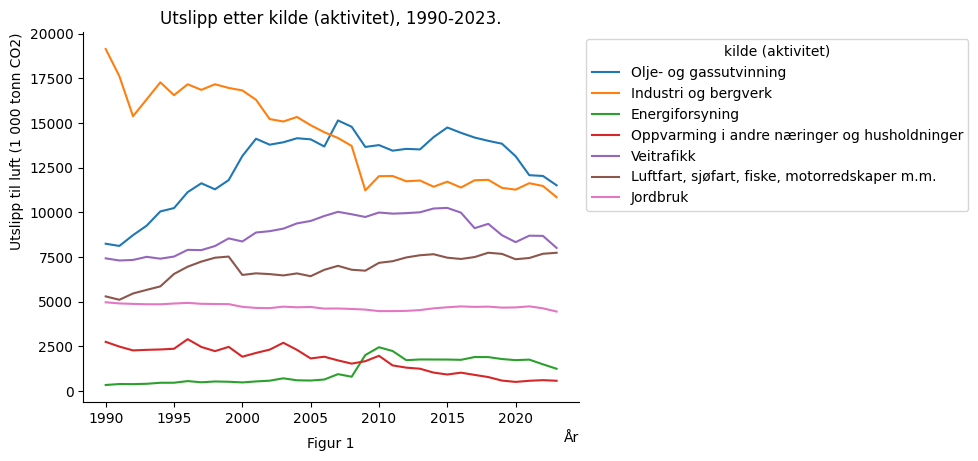

```python
postUrl = 'https://data.ssb.no/api/v0/no/table/13931/'

apiQuery = {
  "query": [
    {
      "code": "UtslpTilLuft",
      "selection": {
        "filter": "vs:UtslpKildeA01",
        "values": [
          "1",
          "2",
          "3",
          "4",
          "5",
          "6",
          "7"
        ]
      }
    },
    {
      "code": "UtslpEnergivare",
      "selection": {
        "filter": "item",
        "values": [
          "VT0"
        ]
      }
    },
    {
      "code": "ContentsCode",
      "selection": {
        "filter": "item",
        "values": [
          "UtslippCO2ekvival"
        ]
      }
    }
  ],
  "response": {
    "format": "json-stat2"
  }
}

def apiToDataframe(postUrl, query):

    # postUrl som spørringen skal postes mot
    # Spørringen og endepunktet til API-et kan hentes fra Statistikkbanken.

    res = requests.post(postUrl, json=query)
    # legger resultat i ds. DS har i tillegg en del metadata
    ds = pyjstat.Dataset.read(res.text)
    # skriver resultatet til to dataframes
    # først dataframe med tekst
    df = ds.write('dataframe')
    # deretter dataframe med koder
    df_id = ds.write('dataframe', naming='id')
    # returnerer også ds i tilfelle en trenger metadata
    return df, df_id, ds

utslipp_df, df_id, ds = apiToDataframe(postUrl, apiQuery)

utslipp_df['år'] = pd.to_numeric(utslipp_df['år'])

fig ,ax = plt.subplots()
ax.spines['right'].set_color('none')
ax.spines['top'].set_color('none')

ax.set_ylabel('Utslipp til luft (1 000 tonn CO2)', loc='top')
ax.set_xlabel('År', loc='right')

ax.set_title('Utslipp etter kilde (aktivitet), 1990-2023.')
ax.text(0.5, -0.125, 'Figur 1', transform=ax.transAxes, ha='center')


sns.lineplot(data=utslipp_df, x="år", y="value", hue="kilde (aktivitet)")
sns.move_legend(ax, "upper left", bbox_to_anchor=(1, 1))
```

Elektrifisering er spesielt bemerkelsesverdig ettersom den ikke bare reduserer utslipp av drivhusgasser, men også i mange tilfeller senker driftskostnadene og forbedrer den økonomiske levetiden til oljefeltene. For eksempel har betydelige prosjekter som de på Draugen og Njord A-plattformene som mål å redusere CO2-utslippene med store marginer årlig når de er fullt operasjonelle(S&P Global)(Offshore Energy).

### Virkninger i utslipps kjeden

Utslippene fra offshore platformene påvirkes først og fremst ved at gassturbiner blir erstattet med kraft fra land.

Gass som blir frigjort kan eksporteres til europa, eller transporteres til land og brukes i Norge. Transport av gass igjennom rørledningene vil kreve energi, dette medfører CO2-utslipp. I hovednettet på land og ved en overføring via sjøkabel vil det dermed oppstå et et nytt behov for energi som må dekkes med å øke produksjonen av kraft på land og/ eller i Europa, ved enten å økt import eller redusere eksport. Dette vil påvirke utslippene, og er avhengig av hvilken energikilde som brukes.Gassen som blir eksportert og eller brukes til ny produksjon nasjonalt vil derfor kunne føre til en økning i CO2-utslipp, men kan erstatte annen produksjon som medfører enda større CO2-utslipp (Torvanger & Ericson, 2013, s. 9). Det er netto CO2-utslipp endringen som den frigjorte gassen medfører, som er det sentrale her.

Gassen som eksporteres til Europa kan brukes til ulike formål. I dagens fordeling av gassforbruket i Europa antas det at 1/3 av gassen går til gassproduksjon. Mens resten av gassen brukes til energi, varme i industrien, bygninger og husholdninger og varmeformål, og påvirker dermed utslippene disse sektorene (Jebsen et al, 2023, s. 10).

Endringer i kraftstrømmene påvirker markedene. Dersom gasstilbudet øker, påvirker det prisene og fører til nye tilpasninger av tilbud og etterspørsel. Prisdannelsen i markedet er basert på en felles algoritme som innebærer at endringer i en del av markedet kan påvirke alle de andre delen i markedet. Derfor gir det ikke mening å analysere effektene av elektrifiseringen av norsk sokkel kun fra et nasjonalt persepektiv.

Markedet for strøm i Europa er styrt av flere faktorer. Dersom man gjennomfører en elektrifiseringen av sokkelen vil markedet først justere opp sine forventninger om høyere fremtidig etterspørsel etter kraft. Forventninger om økt kraftforbruk vil kunne føre til økt kraftproduksjon igjennom økte investeringer i eksisterende produksjon og utbygging av ny produksjonskapasitet.

### Økt gasstilbud og utslipp

Hvordan økt tilbud av gass påvirker netto CO2-utslipp er avhengig av hvilke alternative energikilder gassen fortrenger på marginen. Økt gass forbruk øker isolert sett utslippene, men netto effekten kommer ann på hva som er alternativ energikilde (Jebsen et al, 2023, s. 16).

### Karbonlekkasje

Økninger i kvotepriser påvirker konkurranse evnen til EU med resten av verden, økt pris kan gi opphav ti karbonlekkasje. Dette oppstår ved at varer som er produsert i Europa utkonkurreres av varer produsert utenfor Europa. Lekkasjen skjer ved enten ved at produksjonen flytter ut av europa, eller ved at forbruket bris mot importvarer som blir relativt billigere på grunn, av strengere reguleringer av klima gassutslipp i Europa. I verste fall fører karbonlekkasje til økte globale utslipp (Jebsen et al, 2023, s. 19)

#### Litteraturhenvisning

Direktoratet for forvaltning og økonomistyring (DFØ), u.å. Veileder i samfunnsøkonomiske analyser: En innføring i hvordan statlige tiltak skal utredes. Tilgjengelig på: https://dfo.no/fagomrader/utredning-og-analyse-av-statlige-tiltak/samfunnsokonomiske-analyser/veileder-i-samfunnsokonomiske-analyser/1-en-innforing-i-hvordan-statlige-tiltak-skal-utredes (02.09.2024).

Tennbakk, B., Næss Jebsen, S. H., Kirchner, B., & Eriksrud, A. L. (2023). Elektrifisering av olje- og gassektoren – har det global klimaeffekt? Rapportnummer 2022-23. Offshore Norge. Tilgjengelig fra: https://uit-sok-2014-h24.github.io/articles/Veileder_samfunnsokonomiske_analyser_nov23.pdf

#### Informasjon

generelle utslipps data:

https://www.ssb.no/natur-og-miljo/forurensning-og-klima/statistikk/utslipp-til-luft/artikler/klar-nedgang-i-utslipp-av-klimagasser-i-2023

Equinor:

https://www.equinor.com/no/energi/elektrifisering-av-plattformer

Rapporter:

Cicero og Thema:

https://uit-sok-2014-h24.github.io/articles/thema-rapport-2022-23_elektrifisering.pdf

https://pub.cicero.oslo.no/cicero-xmlui/bitstream/handle/11250/191958/CICERO_Report_2013-03.pdf?sequence=1&isAllowed=y

Bruk av gass i Europa:

https://www.offshorenorge.no/contentassets/4e950643dd0447d994b4673f5064bce8/endrava_rapport_bruk-av-gass-i-europa.pdf